# Assignment 9: Visualization - Revealing a graph

*How to do it?*:

- Open the Rmarkdown file of this assignment (link) in Rstudio.
- Right under each **question**, insert a code chunk (you can use the hotkey `Ctrl + Alt + I` to add a code chunk) and code the solution for the question.
- `Knit` the rmarkdown file (hotkey: `Ctrl + Alt + K`) to export an html.
- Publish the html file to your Githiub Page.

*Submission*: Submit the link on Github of the assignment to Canvas

1. Use the dataset by of covid 19 by WHO at https://covid19.who.int/WHO-COVID-19-global-data.csv. Find the three countries with the most numbers of deaths by Covid-19.

Hint:

- Use `filter` to select the most current date
- Pipe with `arrange(-Cumulative_deaths)` to rank the data by the number of cumulative deaths

```r
library(tidyverse)
df = read_csv("https://covid19.who.int/WHO-COVID-19-global-data.csv")

df %>% group_by(Country) %>% arrange(Cumulative_deaths)
```

```
## # A tibble: 155,709 x 8
## # Groups:   Country [237]
##    Date_reported Country_code Country     WHO_region New_cases Cumulative_cases
##    <date>        <chr>        <chr>       <chr>          <dbl>            <dbl>
##  1 2020-01-03    AF           Afghanistan EMRO               0                0
##  2 2020-01-04    AF           Afghanistan EMRO               0                0
##  3 2020-01-05    AF           Afghanistan EMRO               0                0
##  4 2020-01-06    AF           Afghanistan EMRO               0                0
##  5 2020-01-07    AF           Afghanistan EMRO               0                0
##  6 2020-01-08    AF           Afghanistan EMRO               0                0
##  7 2020-01-09    AF           Afghanistan EMRO               0                0
##  8 2020-01-10    AF           Afghanistan EMRO               0                0
##  9 2020-01-11    AF           Afghanistan EMRO               0                0
## 10 2020-01-12    AF           Afghanistan EMRO               0                0
## # ... with 155,699 more rows, and 2 more variables: New_deaths <dbl>,
## #   Cumulative_deaths <dbl>
```

```r
df %>% group_by(Country) %>% summarize(most_deaths = sum(New_deaths)) %>% arrange(desc(most_deaths))
```

```
## # A tibble: 237 x 2
##    Country                  most_deaths
##    <chr>                          <dbl>
##  1 United States of America      722690
##  2 Brazil                        603465
##  3 India                         452651
##  4 Mexico                        284477
##  5 Russian Federation            226353
##  6 Peru                          199882
##  7 Indonesia                     143077
##  8 The United Kingdom            138852
##  9 Italy                         131655
## 10 Colombia                      126886
## # ... with 227 more rows
```

2. Make a plot revealing the number of deaths in the three countries with the most numbers of deaths

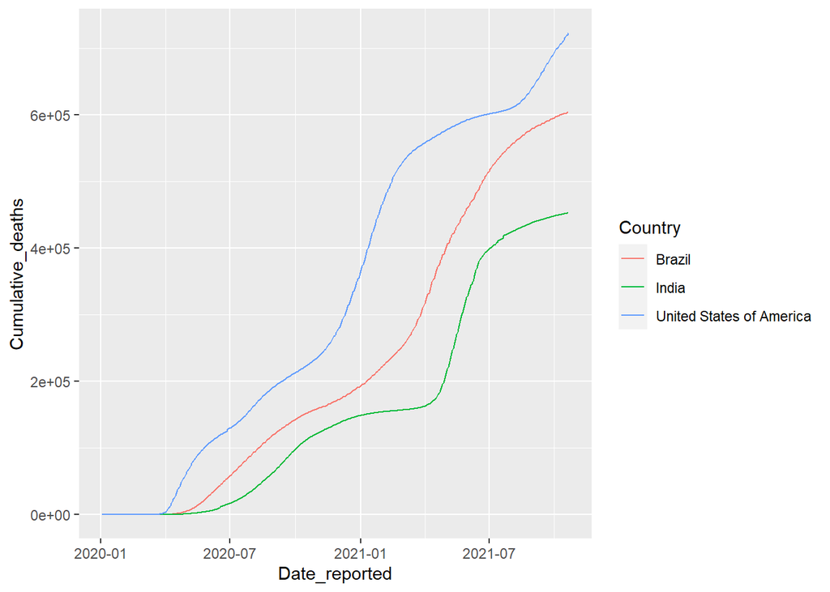

```r
df %>% filter(Country %in% c("United States of America", "Brazil", "India"))%>% ggplot(aes(x = Date_reported, y = Cumulative_deaths, color = Country)) + geom_line()
```

```r
df$death_per_cases = df$Cumulative_deaths / df$Cumulative_cases
```

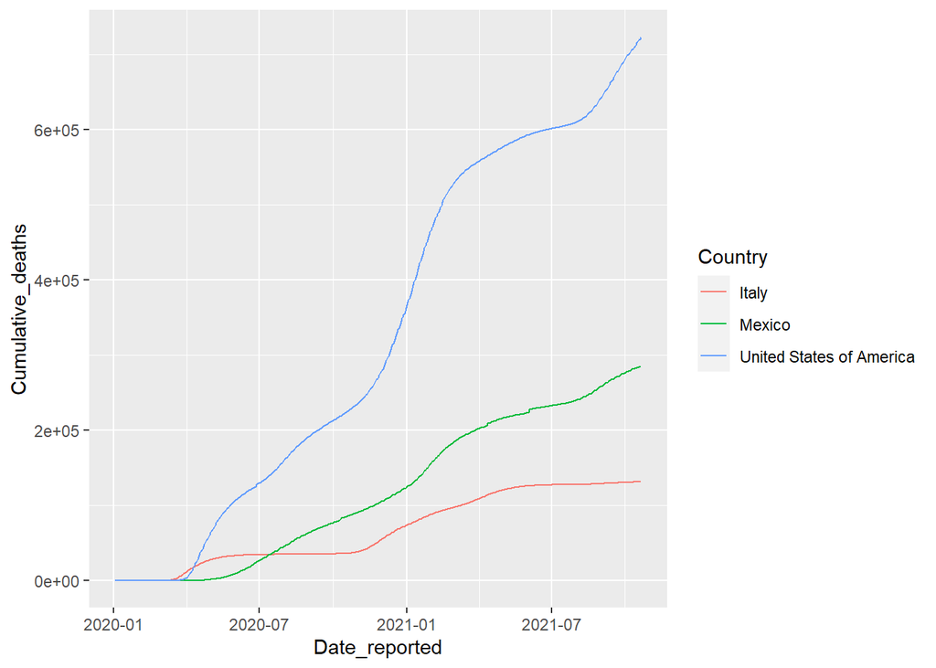

```r
df %>% filter(Country %in% c("United States of America", "Italy", "Mexico"))%>% ggplot(aes(x = Date_reported, y = Cumulative_deaths, color = Country)) + geom_line()
```

https://raw.githubusercontent.com/govex/COVID-19/master/data_tables/vaccine_data/us_data/time_series/vaccine_data_us_timeline.csv

[figure not shown]

```r
library(gganimate)
library(ggplot2)

df %>% filter(Country %in% c("United States of America", "Italy", "Mexico"))%>% ggplot(aes(x = Date_reported, y = Cumulative_deaths, color = Country)) + geom_line()+ transition_reveal(Date_reported)
```